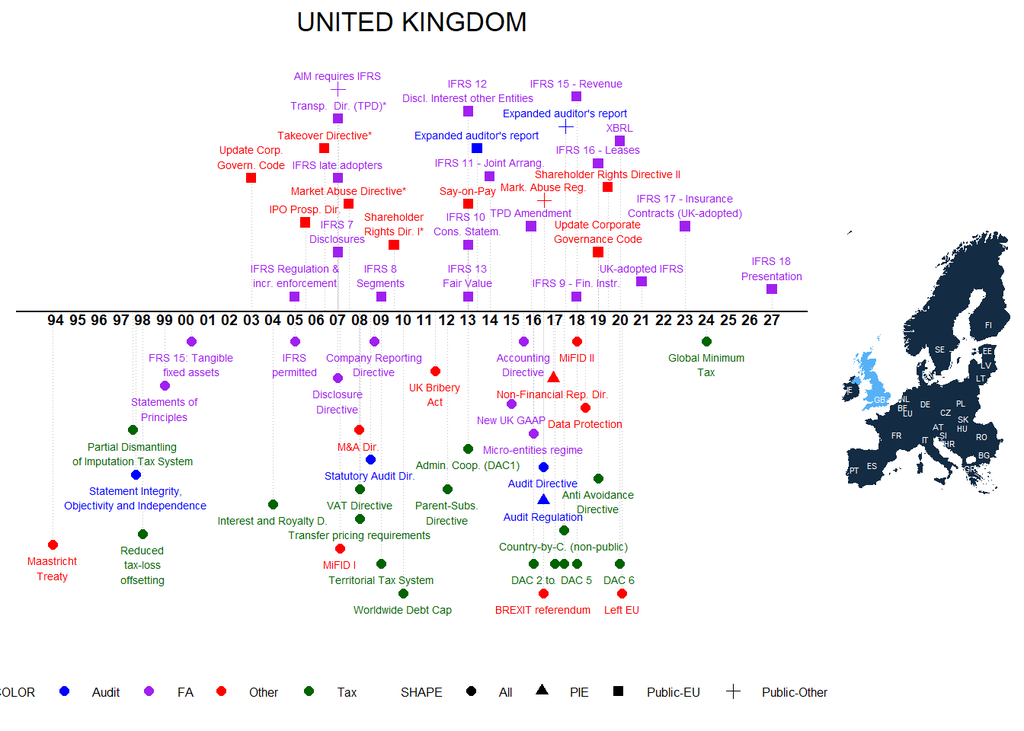

Notes: The graph depicts major regulatory changes that we identified via an extensive literature search, an online survey of mentioned authors, and other sources. Please note that the graph does not include all possible regulatory changes, e.g. minor revisions to local GAAP or tax rate changes below 3% are not included. The dates of EU Directives are based on the official transposition deadlines unless denoted with a *, in which case we included the entry-to-force date as identified in the literature. For more information, please go to [Labro and Pierk (2023)](http://www.eu-regulations.com/Labro_Pierk_2023.pdf). We kindly ask that you cite the paper if you use the information on this website in your research project. Do you have comments or see anything missing? Please email us!

## Regulations, Publications, Further Graphs

The tab ‘Regulations’ includes links to the regulations, gives short descriptions, and provides selective papers for further reading. If the regulation is a national transposition of an EU Directive, the link to the Directive is given. The tab ‘Number of Regulations’ shows graphically the number of regulations 8 years around the respective year (-4,-3,-2,-1,0,+1,+2,+3). The tab ‘Number of Categories” shows graphically the number of different categories 8 years around the respective year (-4,-3,-2,-1,0,+1,+2,+3). The tab ’Publications’ shows all publications that include the countries’ names and variations thereof in the title, abstract, or keywords. Similarly, the tab ‘SSRN’ shows papers of the SSRN Accouning Research Network that include the countries’ names and variations.

### Regulations

[output not shown]

[output cut: 57 more lines]

### Number of Regulations

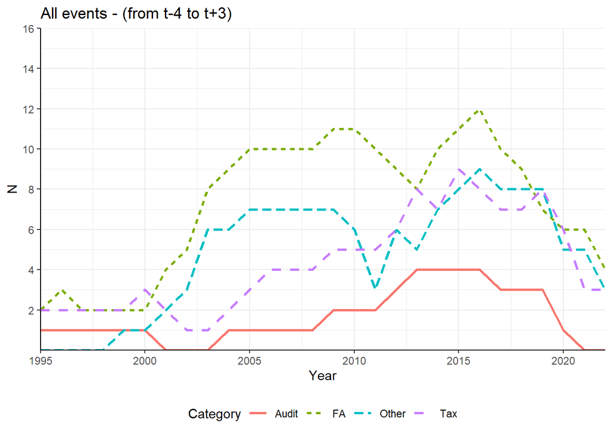

### Number of Categories

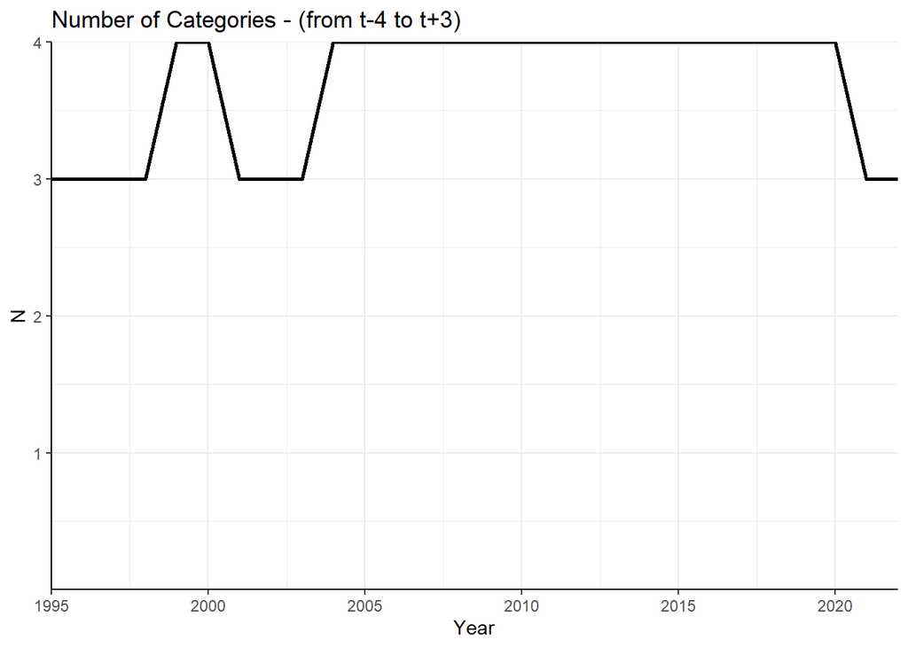

### Publications

|  | authors | title | year | journal |
| --- | --- | --- | --- | --- |
| 1 | Thoradeniya P., Lee J., Tan R., Ferreira A. | from intention to action on sustainability reporting: the role of individual, organisational and institutional factors during war and post-war periods | 2022 | British Accounting Review |
| 2 | Abdel-Maksoud A., Jabbour M., Abdel-Kader M. | stakeholder pressure, eco-control systems, and firms’ performance: empirical evidence from uk manufacturers | 2021 | Accounting Forum |
| 3 | Abdullah A., Khadaroo I. | controlling uk national museums and galleries: the pursuit of conflicting politico-economic and socio-cultural objectives | 2021 | Accounting and Business Research |
| 4 | Adams M., Baker P.L. | does boardroom nationality affect the performance of uk insurers? | 2021 | British Accounting Review |
| 5 | Ahmad S., Connolly C., Demirag I. | toward an understanding of strategic control at a distance in public service delivery | 2021 | Accounting, Auditing and Accountability Journal |
| 6 | Ahmad S., Connolly C., Demirag I. | testing times: governing a pandemic with numbers | 2021 | Accounting, Auditing and Accountability Journal |
| 7 | Ahrens T., Ferry L. | accounting and accountability practices in times of crisis: a foucauldian perspective on the uk government's response to covid-19 for england | 2021 | Accounting, Auditing and Accountability Journal |
| 8 | Alamad S., Hidayah N.N., Lowe A. | a shared boundary object: financial innovation and engineering in islamic financial institutions | 2021 | British Accounting Review |
| 9 | Alexandridis G., Hoepner A.G.F., Huang Z., Oikonomou I. | corporate social responsibility culture and international m&as | 2021 | British Accounting Review |
| 10 | Alhababsah S., Alhaj-Ismail A. | does shared tenure between audit committee chair and engagement partner affect audit outcomes? evidence from the uk | 2021 | British Accounting Review |

[output cut: 983 more lines]

### SSRN

|  | authors | title | Posted | Revised |
| --- | --- | --- | --- | --- |
| 1 | Ahmed A. Elamer, Tarek Abdelfattah, Mohamed Elmahgoub and Collins G. Ntim | extended audit report, auditor disclosure tone and cost of debt: evidence from the uk | 2021-12-27 | 2022-01-10 |
| 2 | Vincent McGrath, Elizabeth A. Sheedy and Fan Yu | governance of cyber security: state of play | 2021-11-28 | 2022-01-18 |
| 3 | Jie Wu, Jie Wu, Orlando C. Richard, Mar ́ıa del Carmen Triana and Xinhe Zhang | the performance impact of gender diversity in the top management team and board of directors: a multiteam systems approach | 2021-11-23 | 2022-01-21 |
| 4 | Yasser Barghathi, Simran Mirani and Naimat Ullah Khan | audit quality and earnings management after communicating key audit matters (kams) in the uae – audacity and auditors’ perspectives | 2021-11-18 |  |
| 5 | Forrest Fabian Jesse, Carla Antonini and Mercedes Luque | a circularity accounting model for co2: artificial neural networks for estimating co2 values in observation of planetary boundaries. | 2021-11-03 |  |
| 6 | Lane Matthews, Mariano Heyden and Dan Zhou | paradoxical transparency? capital market responses to exploration and exploitation disclosure | 2021-10-19 |  |
| 7 | Rong He, Le Luo, Abul Shamsuddin and Qingliang Tang | the value relevance of corporate investment in carbon abatement: the influence of national climate policy | 2021-10-14 |  |
| 8 | Andreas Seebeck and Devrimi Kaya | the power of words: an empirical analysis of the communicative value of extended auditor reports | 2021-10-01 |  |
| 9 | Justice Mudzamiri and Patrick C. Osode | reconciling the 'bittersweet chemistry' between technology and corporate takeovers through reinforcing national security interests in merger control | 2021-09-24 |  |
| 10 | Anna Grosman and Mario Daniele Amore | share repurchases and board independence | 2021-09-24 |  |

[output cut: 89 more lines]